# INTP General Survey Analysis 2017

This was written for the [Being an INTP Facebook Page](https://facebook.com/INTP.info) by [Anne Dorko](https://www.annedorko.com).

If you know your MBTI Personality type, you can contribute to the dataset by [completing the survey](https://anne274.typeform.com/to/ycfkp1). Data is kept anonymous. New survey submissions are regularly cleaned and fed through this analysis for the highest quality results. All numbers and reports below are based on the latest cleaned data.

## General Information

This data is primarily for fun, and cannot be considered scientific. That said, I have done my best to make the data as quantifiable as possible. This exercise has been more for the practice of data cleaning and analysis, and I like to share my work.

91% of the respondents were INTP, which is not represenative of the general popualation. Because of this, the otherwise general results are heavily weighted towards any INTP tendencies. Notes have been made through this page to let you know when INTPs have been completely isolated to run INTP-specific analysis.

You can also see that more females than males took this survey. We do not have enough data to determine whether this means INTPs are more likely to be women, as our sample is a convenience sample and not a true random sample.

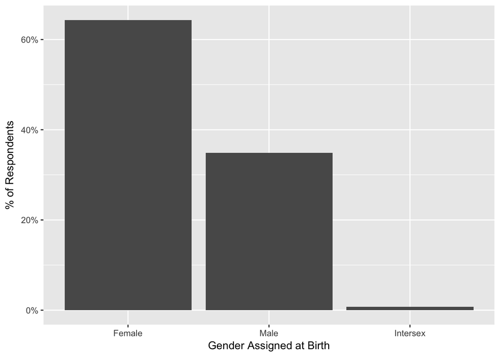

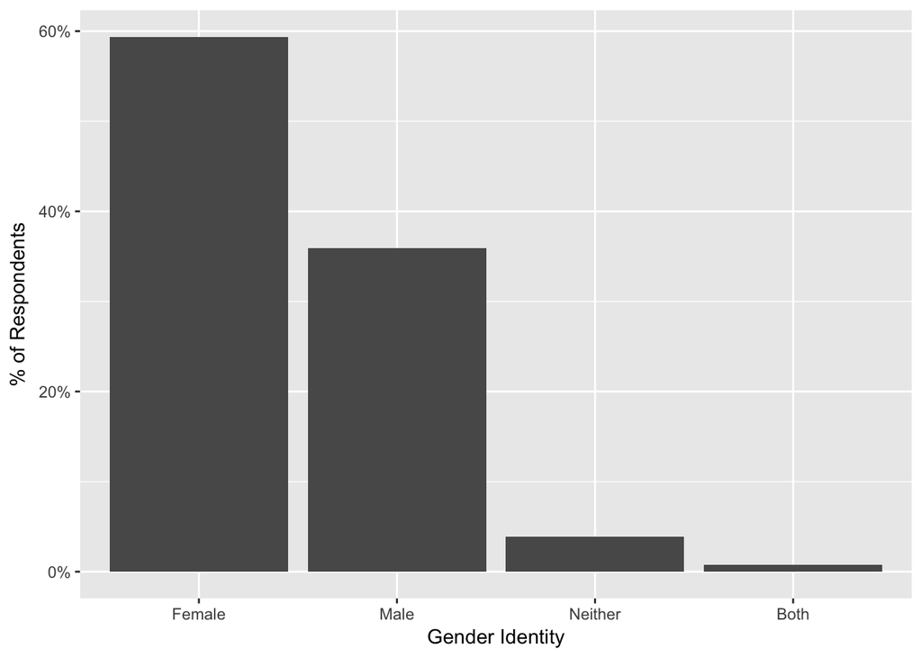

It is also important to note that the majority of test takers were assigned their MBTI type through an online test or assigned it to themselves after reading through all 16 profiles. This means that our sample may or may not be ‘true’ INTPs (if such a thing exists). However, as this is only in good fun, for the sake of this study we will assume that the MBTI personality types are accurate.

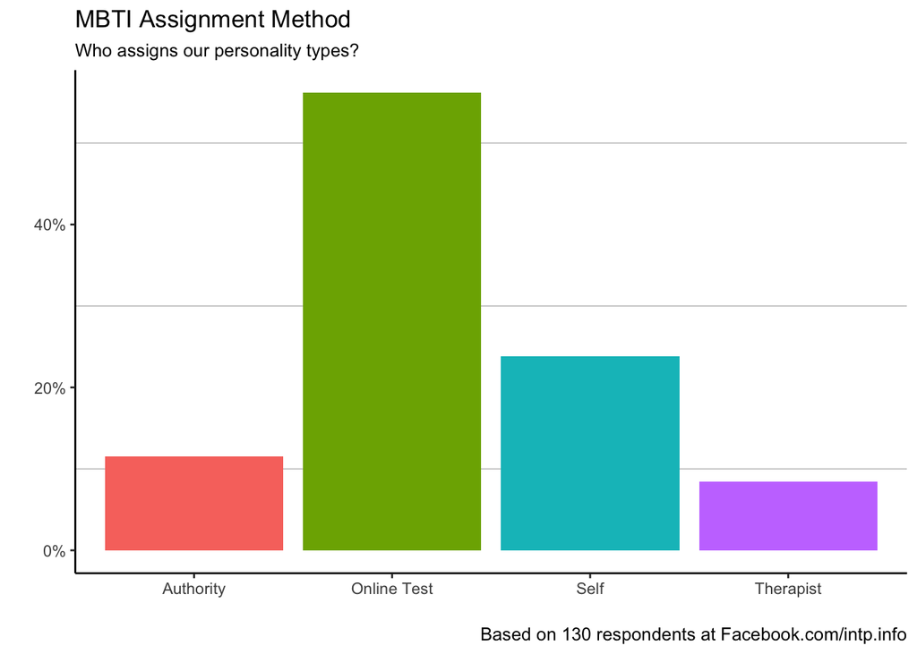

Now that these disclaimers are out of the way, let’s dive in. I’ll use authoritative language as if this were a scientifically accurate survey, but you should take it with a grain of salt.

## The Parents of an INTP

In the survey, respondents are asked to give information about their parents. In total, MBTI personality types were provided for 216 individuals that are parents to INTP respondents. This accounts for 1.8 parents reported per INTP.

### Female Parent Figures

As you can see below, female parents of INTPs tend to be ISFJ, ISTJ, INFJ, and ESFJ. It appears that very few INTPs have mothers who are *also* INTPs!

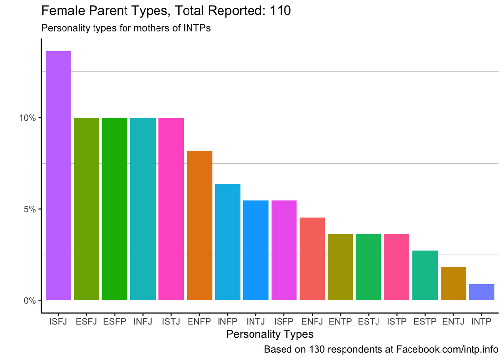

### Male Parent Figures

Contrary to female parent figures, more fathers of INTPs also tend to be INTPs themselves, followed in frequency by ISTJ and ISTP. This is particularly interesting as, in general, female INTPs signficantly outweigh male INTPs throughout the rest of the data.

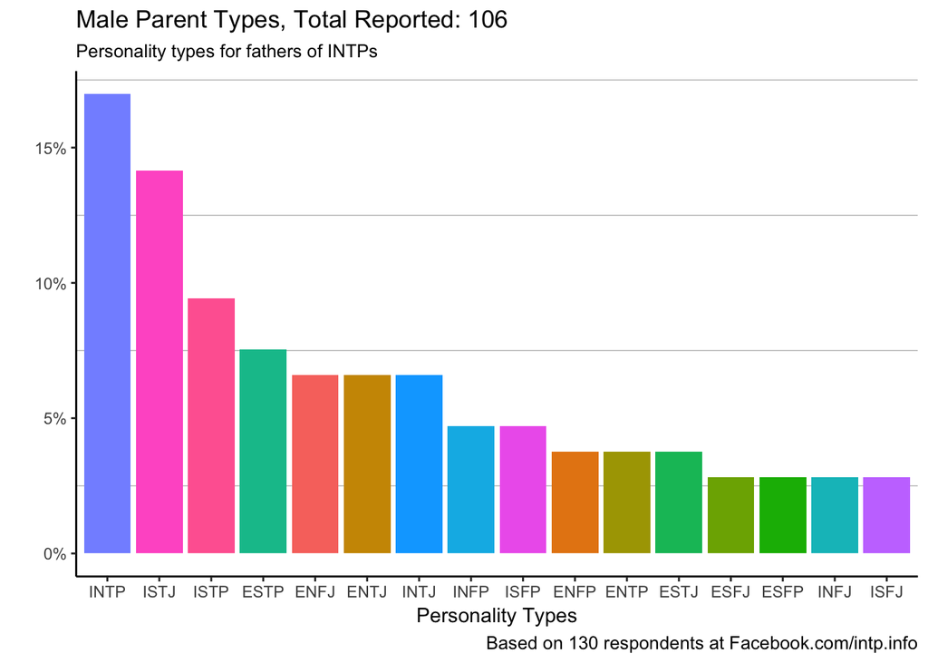

## MBTI Personalities and Romance

Going in, it is again important to remember that the highest amounts of information we have are for INTPs. What we are looking for is patterns in frequent pairings. Due to the imbalance of data for INTPs, one cannot assume that these patterns apply evenly for other types of MBTI personality types.

Of those who took the survey, 35.3% provided no relationship, meaning that 64.7% were in a relationship significant enough to report when they submitted their information.

### Sexual Attraction and Orientation

Let’s review overall sexuality and attraction. First, let’s take a look at sexual attraction, defined here as interest in having sexual activity with others.

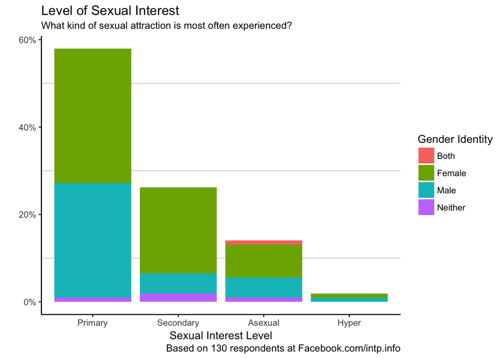

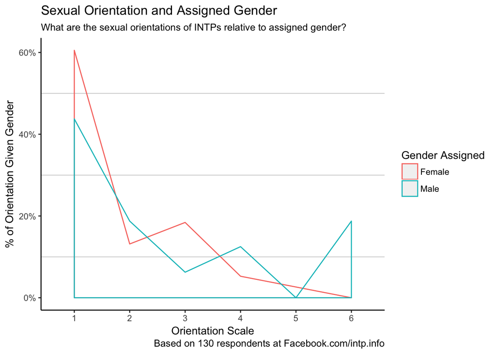

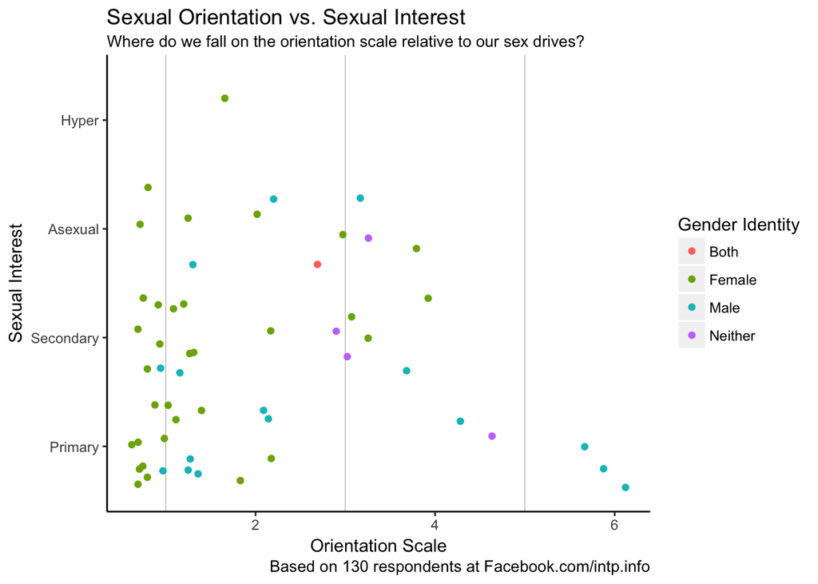

We can see here that those who have non-binary gender identities seem to be attracted to multiple other genders.

We now know that roughly half our respondents are straight and their relationships are most often driven by sexual motives. Let’s take a look at the 184 couples whose data we have access to, and see how things shake out.

Here’s a collection of all the MBTI personality pairings we have to work with.

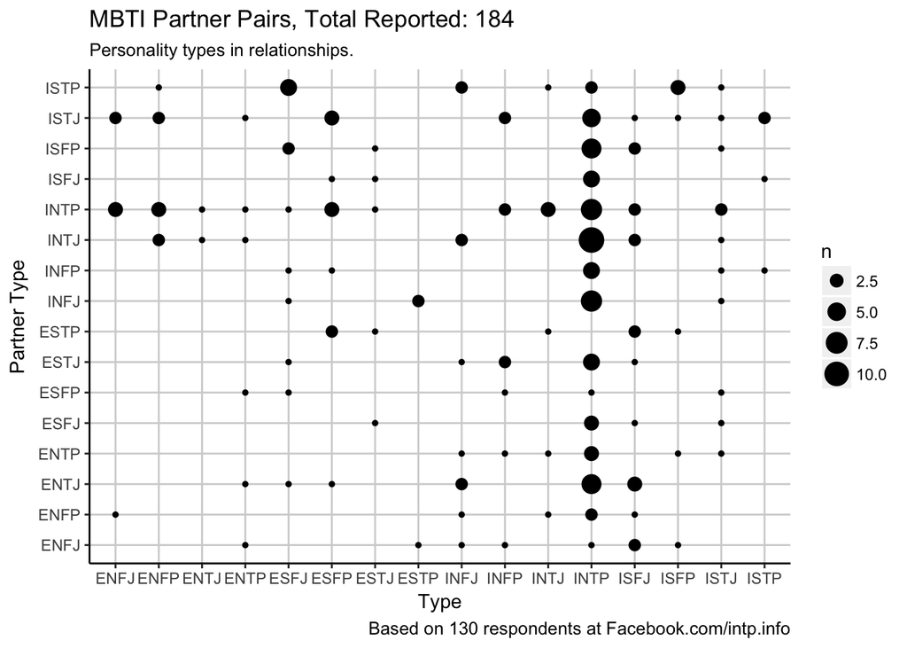

This is neat, but since most of our data is specific to INTPs, lets narrow this down to partner types that INTPs are usually found dating. We have 88 to work with.

### Male INTPs Tend to Date…

The male INTP seems to favor INFPs the highest, followed by a fairly even turnout of ENFJ, ENFP, and ISFJ. While earlier we found that INTPs tend to have INTP fathers, INTP men are very rarely found dating another INTP.

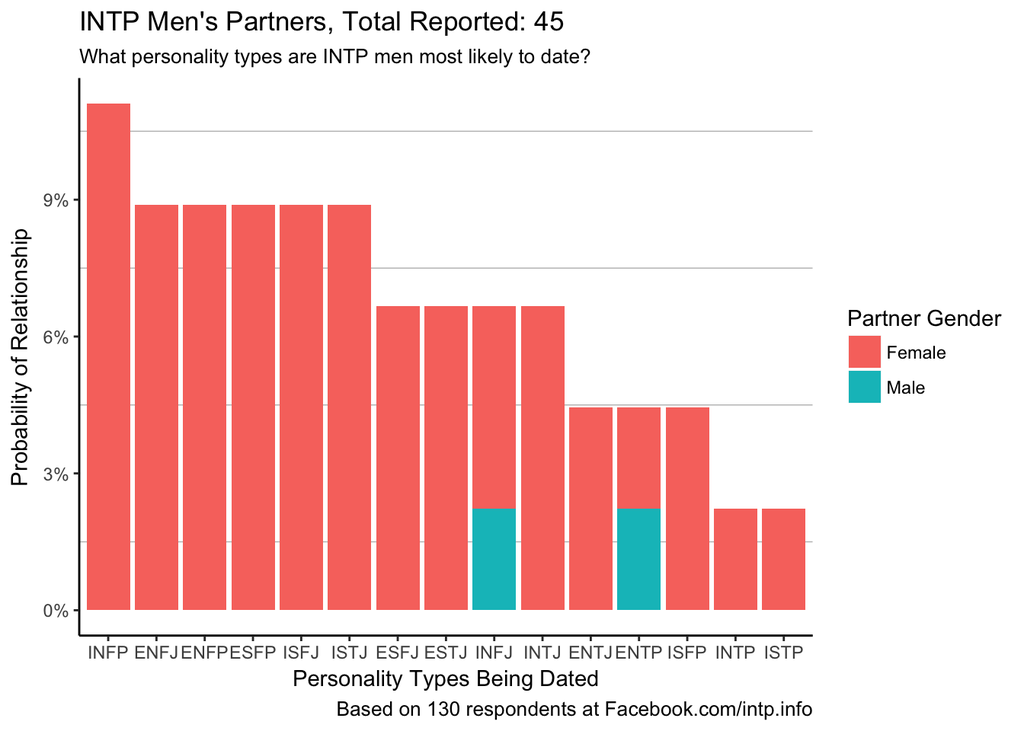

### Female INTPs Tend to Date…

The female INTP seems to favor certain types a little more heavily, with preference for INTJ followed by other INTPs. Even the third preference is a hybrid of these first two: ENTJ.

[figure not shown]

### Relationship Success Factors

It’s important to note that the average INTP respondent in a relationship is 32 years old. Our data is most representative of those between the ages of 26 and 39.5. Given this, let’s look at when the most successful relationships begin!

We’ll define successful relationships as those lasting longer than three years, and we’ll only look at relationships for those that fall between our typical age range as stated above. It appears that the majority of long-term relationships started quite young for INTPs who are currently older than 26 and younger than 39.5. It is difficult to tell whether this is indicative of INTPs being good at finding a suitable mate and settling down early, but that seems to be what the data suggests.

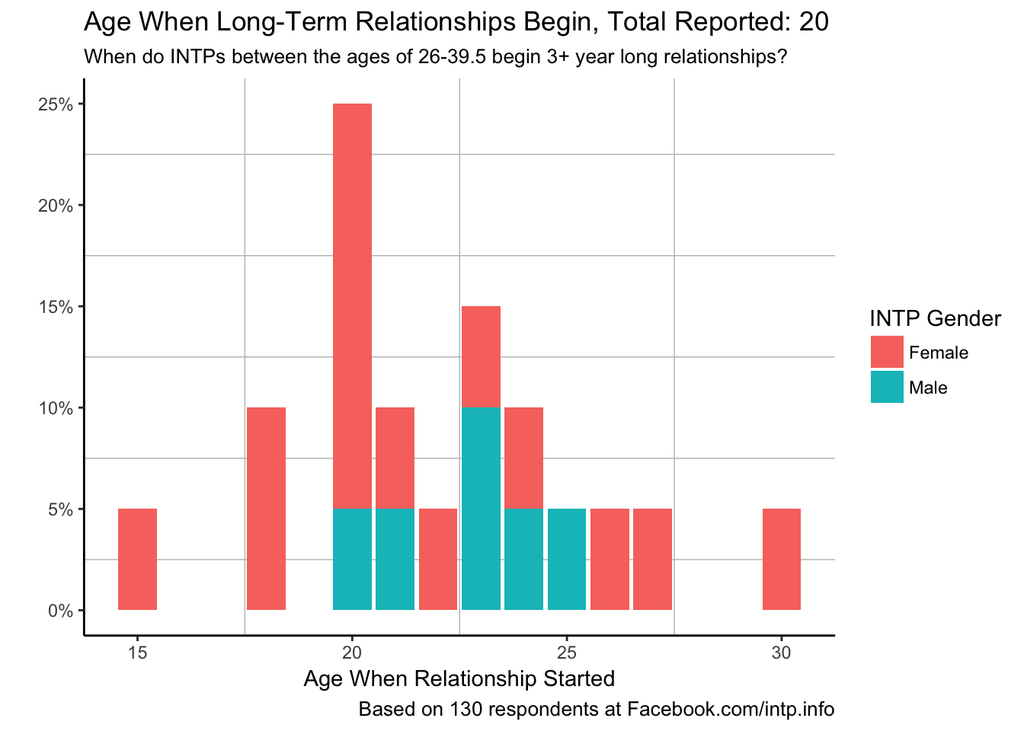

So, are INTPs cautious about jumping into a relationship? Perhaps that is what makes them so successful at such a young age. Let’s take a look at how long INTPs wait to start relationships. We’ll exclude extreme outliers for those who knew each other over 15 years before dating in the following graph.

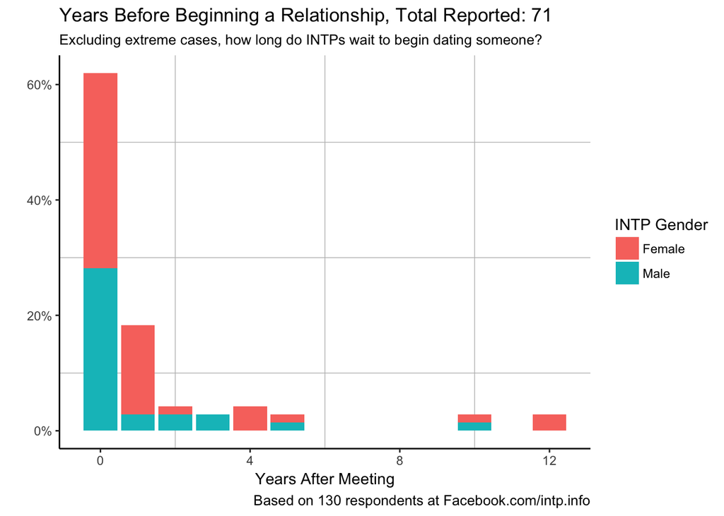

Most INTPs begin dating immediately. For those who don’t, on average, an INTP waits about 2.7 years before dating someone. It doesn’t seem that patience plays a huge role in whether a relationship worked out. The most successful relationships (meaning those lasting over three years) say that they met through organic means, such as church, school, or through their mutual friends and hobbies.

Perhaps there are certain pairings that tend to last longer! Let’s explore the pairings of the most successful relationships.

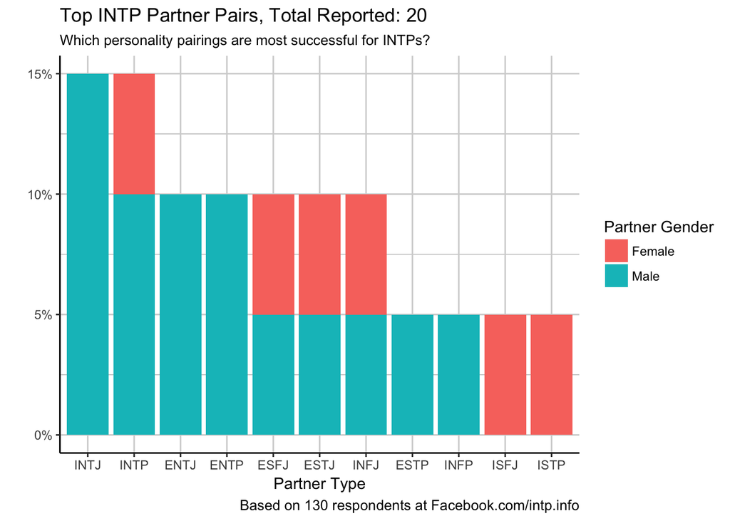

There doesn’t seem to be a strong correlation between length of time waited to date vs. length of relationship, either. The average relationship length seems to be about 7.8 years. The graph below indicates the longest relationships start between 1-5 years after meeting.

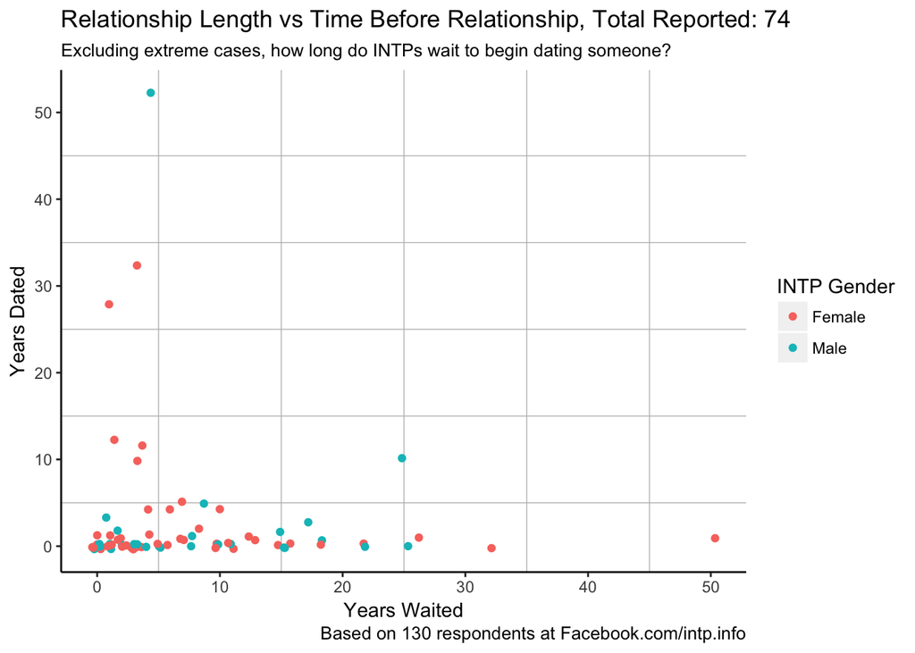